# NOAA Storm Database Extreme Weather Damage Analysis

Paul

01/02/2020

## NOAA Storm Database extreme weather casualties and economic consequences records.

### Introduction

This document explores and analyzes extreme weather events data in the NOAA Storm Database. The data can be downloaded from [NOAA Storm Database Link](https://d396qusza40orc.cloudfront.net/repdata%2Fdata%2FStormData.csv.bz2). Further information can be found on [NOAA Storm Database website](https://www.ncdc.noaa.gov/stormevents/). The data contain records of the occurrence of storms and other significant weather phenomena having sufficient intensity to cause loss of life, injuries, significant property damage, and/or disruption to commerce.

The goal of this report is to answer 2 main questions:

1. Across the United States, which types of events are most harmful with respect to population health?
2. Across the United States, which types of events have the greatest economic consequences?

The **r** code as well as explanation, and justification of each step of data processing and analysis will both be shown and described in this document.

### Data Downloading

First the data is downloaded and the first 20 rows read via the following code.

```r
library(R.utils)
download.file("https://d396qusza40orc.cloudfront.net/repdata%2Fdata%2FStormData.csv.bz2","repdata_data_StormData.csv.bz2",mode="wb")
bunzip2("repdata_data_StormData.csv.bz2","repdata_data_StormData.csv",overwrite=TRUE,remove=FALSE)
dat <- read.csv("repdata_data_StormData.csv",nrows=20)
```

### Data Processing

The reason that only 20 rows were read first is because the data is 550 Mb in size, and will consume too much computer memory if everything is read and stored. The aim is thus to probe the data first to see what it contains and then only read the information necessary for the analysis questions.

The following code looks into the header of the data

```r
names(dat)
```

```
##  [1] "STATE__"    "BGN_DATE"   "BGN_TIME"   "TIME_ZONE"  "COUNTY"
##  [6] "COUNTYNAME" "STATE"      "EVTYPE"     "BGN_RANGE"  "BGN_AZI"
## [11] "BGN_LOCATI" "END_DATE"   "END_TIME"   "COUNTY_END" "COUNTYENDN"
## [16] "END_RANGE"  "END_AZI"    "END_LOCATI" "LENGTH"     "WIDTH"
## [21] "F"          "MAG"        "FATALITIES" "INJURIES"   "PROPDMG"
## [26] "PROPDMGEXP" "CROPDMG"    "CROPDMGEXP" "WFO"        "STATEOFFIC"
## [31] "ZONENAMES"  "LATITUDE"   "LONGITUDE"  "LATITUDE_E" "LONGITUDE_"
## [36] "REMARKS"    "REFNUM"
```

The data such as the state and county, the time of occurence, latitude and longitude, are not needed. Only 8 columns out of 37 will be read: 1. BGN_DATE, 2. EVTYPE, 3. FATALITIES, 4. INJURIES, 5. PROPDMG, 6. PROPDMGEXP, 7. CROPDMG, 8. CROPDMGEXP

```r
#define column to be read
mycolclass <- c("NULL", NA,"NULL","NULL","NULL","NULL","NULL",NA,"NULL","NULL","NULL","NULL","NULL","NULL","NULL","NULL","NULL","NULL","NULL","NULL","NULL","NULL",NA,NA,NA,NA,NA,NA,"NULL","NULL","NULL","NULL","NULL","NULL","NULL","NULL","NULL")
dat <- read.csv("repdata_data_StormData.csv", colClasses=mycolclass, stringsAsFactors = FALSE, strip.white = TRUE)
```

The BGN_DATE is in a format unusable by R, which will need to be transformed by the following code, which adds a new DATE column and removes BGN_DATE.

```r
#The content of BGN_DATE
head(dat$BGN_DATE)
```

```
## [1] "4/18/1950 0:00:00"  "4/18/1950 0:00:00"  "2/20/1951 0:00:00"
## [4] "6/8/1951 0:00:00"   "11/15/1951 0:00:00" "11/15/1951 0:00:00"
```

```r
#transform
dat$BGN_DATE <- sub(" 0:00:00","",dat$BGN_DATE)
dat$DATE <- as.Date(dat$BGN_DATE,format="%m/%d/%Y")
dat$BGN_DATE <- NULL
#The new column is now a proper 'date' class
class(dat$DATE)
```

```
## [1] "Date"
```

In addition, the PROPDMGEXP and CROPDMGEXP contain the exponent to be multipled to PROPDMG and CROPDMG respectively. But they first need to be cleaned, with unintelligible rows removed.

```r
table(dat$CROPDMGEXP)
```

```
##
##             ?      0      2      B      k      K      m      M
## 618413      7     19      1      9     21 281832      1   1994
```

```r
table(dat$PROPDMGEXP)
```

```
##
##             -      ?      +      0      1      2      3      4      5      6
## 465934      1      8      5    216     25     13      4      4     28      4
##      7      8      B      h      H      K      m      M
##      5      1     40      1      6 424665      7  11330
```

```r
dat <- dat[c(grep("K|M|B",dat$PROPDMGEXP),which(dat$PROPDMGEXP=="")),]
dat <- dat[c(grep("K|M|B",dat$CROPDMGEXP),which(dat$CROPDMGEXP=="")),]
```

And then the exponent to be multiplied.

```r
dat$PROPDMG[dat$PROPDMGEXP=="K"] <- dat$PROPDMG[dat$PROPDMGEXP=="K"] * 1000
dat$PROPDMG[dat$PROPDMGEXP=="M"] <- dat$PROPDMG[dat$PROPDMGEXP=="M"] * 1000000
dat$PROPDMG[dat$PROPDMGEXP=="B"] <- dat$PROPDMG[dat$PROPDMGEXP=="B"] * 1000000000
dat$CROPDMG[dat$CROPDMGEXP=="K"] <- dat$CROPDMG[dat$CROPDMGEXP=="K"] * 1000
dat$CROPDMG[dat$CROPDMGEXP=="M"] <- dat$CROPDMG[dat$CROPDMGEXP=="M"] * 1000000
dat$CROPDMG[dat$CROPDMGEXP=="B"] <- dat$CROPDMG[dat$CROPDMGEXP=="B"] * 1000000000
dat$PROPDMGEXP<-NULL
dat$CROPDMGEXP<-NULL
```

Furthermore, the event type listed on NOAA database description contains 48 types of extreme weather events, but the record in EVTYPE shows 981 unique values.

```r
length(unique(dat$EVTYPE))
```

```
## [1] 981
```

These values need to be analyzed and processed to reduce the number into (hopefully) a handful of categories. This can be done by analyzing unique words, case removed.

```r
words<-strsplit(dat$EVTYPE,"[\\/ -;,]")
words<-as.data.frame(table(tolower(unlist(words))))
#75 most frequent words are shown.
words<-words[order(words[,2],decreasing=TRUE),]
head(words,75)
```

```
##             Var1   Freq
## 345         wind 341683
## 130         hail 290344
## 308         tstm 227234
## 287 thunderstorm 109292
## 103        flood  82113
## 300      tornado  60669
## 98         flash  55651
## 137        heavy  27980
## 138         high  23062
## 347        winds  22709
## 351       winter  19601
## 256         snow  17578
## 168    lightning  15754
## 268        storm  15029
```

[output cut: 61 more lines]

These words are then categorized into 11 extreme weather categories. Some words that are hard to sort are ignored, while some fall into more than one categories.

```r
#after looking at event input words from test3
dat$wind <- grepl("wind|tstm|storm|tornado|waterspout|blizzard|hurricane|microburst",dat$EVTYPE,ignore.case=TRUE)
dat$tropicalstorm <- grepl("tropical|hurricane",dat$EVTYPE,ignore.case=TRUE)
dat$tornado <- grepl("tornado|waterspout|funnel",dat$EVTYPE,ignore.case=TRUE)
dat$thunder <- grepl("tstm|thunder|lightning",dat$EVTYPE,ignore.case=TRUE)
dat$rain <- grepl("rain",dat$EVTYPE,ignore.case=TRUE)
dat$cold <- grepl("hail|winter|snow|blizzard|cold|ice|chill|freez|frost|sleet",dat$EVTYPE,ignore.case=TRUE)
dat$floodortide <- grepl("flood|fld|tide|surge",dat$EVTYPE,ignore.case=TRUE)
dat$fire <- grepl("fire",dat$EVTYPE,ignore.case=TRUE)
dat$droughtorheat <- grepl("heat|drought|dry",dat$EVTYPE,ignore.case=TRUE)
dat$geo <- grepl("avalanche|landslide",dat$EVTYPE,ignore.case=TRUE)
dat$water <- grepl("marine|water|surf|coastal|lake|river|current",dat$EVTYPE,ignore.case=TRUE)
apply(dat[,-1:-6],2,sum)
```

```
##          wind tropicalstorm       tornado       thunder          rain
##        447543          1044         71510        352332         12240
##          cold   floodortide          fire droughtorheat           geo
##        337160         86788          4240          5449          1000
##         water
##         20103
```

The categories are

1. **wind** contains any word that signifies presence of wind, including blizzards and waterspouts.
2. **tropical storm** contains tropical storms and hurricanes.
3. **tornado** includes, aside from tornados, waterspouts and ‘funnel’.
4. **thunder** contains anything thunder- or lightning-related.
5. **rain** contains a single word ‘rain’.
6. **cold** contains disasters related to cold weather.
7. **floodortide** contains words that signifies floods or abnormally low or hide tides.
8. **fire** contains a single word ‘fire’.
9. **droughtorheat** contains drought, dry spells, and heat waves.
10. **geo** contains avalanches and landslides.
11. **water** contains any event that occurs on water, be them sea, river, lakes, etc.

The data is then summarized into a new table, containing fatalities, injuries, and property and crop damage count.

```r
dmgcount <- as.data.frame(matrix(ncol=5,nrow=length(colnames(dat)[-1:-6])))
colnames(dmgcount)<-c("EVTYPE",colnames(dat)[2:5])
dmgcount$EVTYPE <- colnames(dat)[-1:-6]
dmgcount[,2] <- apply(dat[,2]*dat[,-1:-6],2,sum)
dmgcount[,3] <- apply(dat[,3]*dat[,-1:-6],2,sum)
dmgcount[,4] <- apply(dat[,4]*dat[,-1:-6],2,sum)
dmgcount[,5] <- apply(dat[,5]*dat[,-1:-6],2,sum)
dmgcount$COUNT <- apply(dat[,-1:-6],2,sum)
dmgcount
```

```
##           EVTYPE FATALITIES INJURIES      PROPDMG     CROPDMG  COUNT
## 1           wind       7741   109250 227808887353 13898279118 447543
## 2  tropicalstorm        201     1711  92452307560  6200188800   1044
## 3        tornado       5661    91378  58591187033   367458360  71510
## 4        thunder       1573    14775  13512735040  1286294498 352332
## 5           rain        114      305   3270230190   919315800  12240
## 6           cold       1155     7841  30328179011 11840920303 337160
## 7    floodortide       1577     8726 215562117194 12388852200  86788
## 8           fire         90     1608   8501628500   403281630   4240
## 9  droughtorheat       3170     9257   1073164350 14877050280   5449
## 10           geo        263      224    333473800    20017000   1000
## 11         water        805      923   5903124000  5059090000  20103
```

However, a [description](https://www.ncdc.noaa.gov/stormevents/details.jsp?type=eventtype) on NOAA site states that before 1996, only tornados, thunderstorms and hails and recorded. This may introduce observational bias into the analysis. It is therefore imparative to cut off the data from before 1996 to eliminate this bias.

```r
dat2 <- subset(dat,DATE>=as.Date("1996-01-01"))
```

Following, a new damage count table is likewise created.

```r
dmgcount2 <- as.data.frame(matrix(ncol=5,nrow=length(colnames(dat2)[-1:-6])))
colnames(dmgcount2)<-c("EVTYPE",colnames(dat2)[2:5])
dmgcount2$EVTYPE <- colnames(dat2)[-1:-6]
dmgcount2[,2] <- apply(dat2[,2]*dat2[,-1:-6],2,sum)
dmgcount2[,3] <- apply(dat2[,3]*dat2[,-1:-6],2,sum)
dmgcount2[,4] <- apply(dat2[,4]*dat2[,-1:-6],2,sum)
dmgcount2[,5] <- apply(dat2[,5]*dat2[,-1:-6],2,sum)
dmgcount2$COUNT <- apply(dat2[,-1:-6],2,sum)
```

Furthermore, it should be helpful to also look into the damage per occurence of event, as the events are not equally frequent and some types of events are more severe when they do occur.

```r
dmgcount3 <- dmgcount2
dmgcount3[,2:5] <- dmgcount3[,2:5]/dmgcount3$COUNT
```

### Results

To produce the required plots some extra libraries have to be loaded

```r
library(gridExtra)
```

```r
library(ggplot2)
library(reshape2)
```

Then the plots (4 plots in 2 figures) are created by the following code

```r
#plot fatalities and injuries
temp <-dmgcount2[order(-dmgcount2$FATALITIES),]
temp$EVTYPE<-factor(temp$EVTYPE,levels = temp$EVTYPE)
temp[,3]<-temp[,3]/10
temp<-melt(temp[,1:3])

fatalp <- ggplot(temp,aes(x=EVTYPE,y=value,fill=variable))
fatalp <- fatalp + geom_bar(position=position_dodge(),stat="identity")
fatalp <- fatalp + scale_y_continuous(sec.axis = sec_axis(~.*10, name = "Injuries"))
fatalp <- fatalp + labs(y="Fatalities",x="Event Type (ordered by fatalities)") + scale_fill_discrete(labels = c("Fatalities","Injuries")) + ggtitle("Total Fatalities, Injuries, Property and Crop Damage from Extreme Weather in the US, 1996-2011")

#plot property damage and crop damage
temp <-dmgcount2[order(-(dmgcount2$PROPDMG+dmgcount2$CROPDMG)),]
temp$EVTYPE<-factor(temp$EVTYPE,levels = temp$EVTYPE)
temp[,5]<-temp[,5]*10
temp<-melt(temp[,c(1,4,5)])
temp$value <- temp$value/1000000000

dmgp <- ggplot(temp,aes(x=EVTYPE,y=value,fill=variable))
dmgp <- dmgp + geom_bar(position=position_dodge(),stat="identity")
dmgp <- dmgp + scale_y_continuous(sec.axis = sec_axis(~./10, name = "Crop Damage (Billion $)"))
dmgp <- dmgp + labs(y="Property Damage (Billion $)",x="Event Type (ordered by total damage)") + scale_fill_discrete(labels = c("Property Damage","Crop Damage"))

#plot weighted fatalities and injuries
temp <-dmgcount3[order(-dmgcount3$FATALITIES),]
temp$EVTYPE<-factor(temp$EVTYPE,levels = temp$EVTYPE)
temp[,3]<-temp[,3]/5
temp<-melt(temp[,1:3])

fatalp2 <- ggplot(temp,aes(x=EVTYPE,y=value,fill=variable))
fatalp2 <- fatalp2 + geom_bar(position=position_dodge(),stat="identity")
fatalp2 <- fatalp2 + scale_y_continuous(sec.axis = sec_axis(~.*5, name = "Injuries"))
fatalp2 <- fatalp2 + labs(y="Fatalities",x="Event Type (ordered by fatalities)") + scale_fill_discrete(labels = c("Fatalities","Injuries")) + ggtitle("Fatalities, Injuries, Property and Crop Damage per Extreme Weather Event, 1996-2011")

#plot weighted property and crop damage
temp <-dmgcount3[order(-(dmgcount3$CROPDMG+dmgcount3$PROPDMG)),]
temp$EVTYPE<-factor(temp$EVTYPE,levels = temp$EVTYPE)
temp[,5]<-temp[,5]*10
temp<-melt(temp[,c(1,4,5)])
temp$value <- temp$value/1000000

dmgp2 <- ggplot(temp,aes(x=EVTYPE,y=value,fill=variable))
dmgp2 <- dmgp2 + geom_bar(position=position_dodge(),stat="identity")
dmgp2 <- dmgp2 + scale_y_continuous(sec.axis = sec_axis(~./10, name = "Crop Damage (Million $)"))
dmgp2 <- dmgp2 + labs(y="Property Damage (Million $)",x="Event Type (ordered by total damage)") + scale_fill_discrete(labels = c("Property Damage","Crop Damage"))
```

The fatalp, dmgm, fatalp2, and dmgp2 contain the plots of the results.

1. The first results are the total fatalities, injuries, property and crop damage.

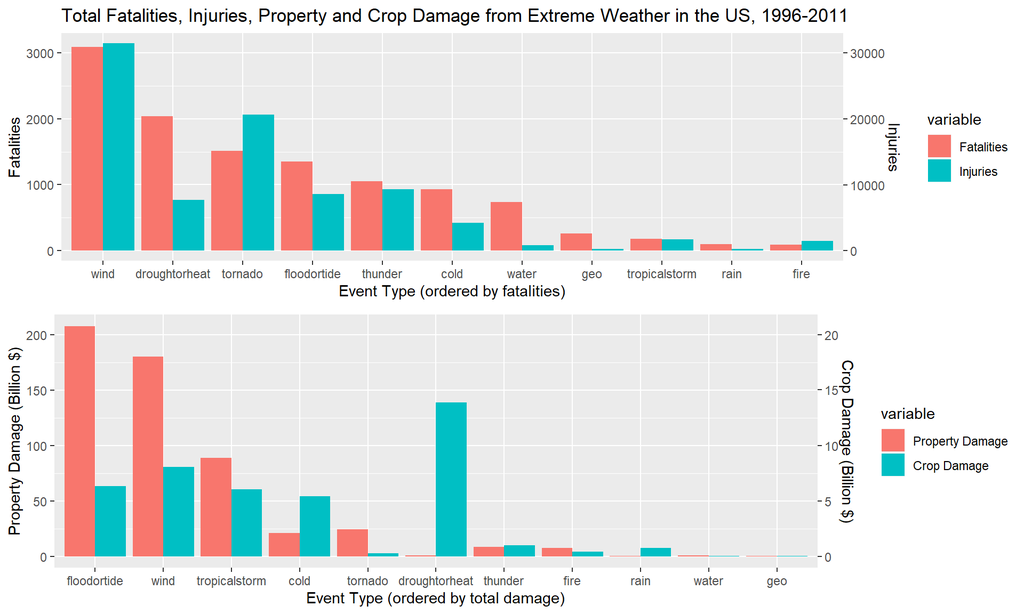

```r
grid.arrange(fatalp, dmgp, nrow = 2)
```

The wind events cause the most cumulative number of fatalities and injuries. The drought and heat events follows second in fatality count, while tornado comes second in injury count.

In terms of financial damage, flood and tide outstrips wind events despite having a much lower event count. Drought and heat causes the most damage to crops. Financial damage from water- and geo-based events are virtually non-existent, owing to the location and nature of such disaster categories.

2. The second results shows the fatalities, injuries, property and crop damage per single occurence of each category of events.

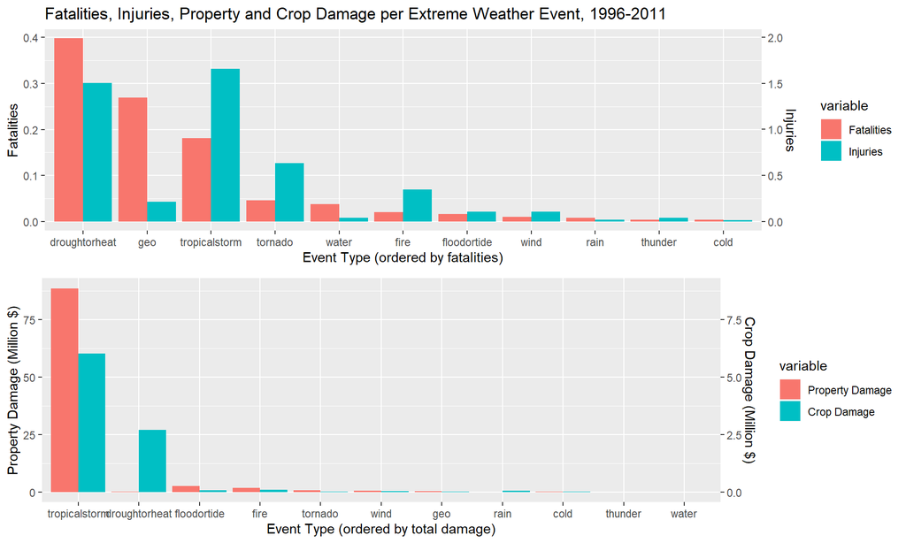

```r
grid.arrange(fatalp2, dmgp2, nrow = 2)
```

Tropical storm far outstrips other types of events in terms of financial damage per occurence, followed at a distance by drought and heat which seems to (unsurprisingly) only cause crop damage.

### Summary

When lives are concerned, spending resources in protection against wind will be most effective, followed by heat waves and droughts. However, high-fatality-intensive events such as landslides and avalanches also merit resources lest one be criticized for incompetency and negligence.

Financially, flood and wind causes the most economic damage, with drought and heat also deserving of attention else one would lose support from the farmers. Tropical storms and hurricanes are the most destructive when they do occur and by the same logic as the above paragraph should be prioritized well.